# Test variable importance stability using RCE

Yi Chen

2024-08-09

# 1 Introduction

[Link to RCE paper](https://link.springer.com/article/10.1007/s10994-013-5337-8)

Our goal here is to repeat the bagging process (i.e., the whole RCE algorithm) many times in order to understand stability of the variable importance.

# 2 Parkinsons data set

## 2.1 Variable importance

```r
set.seed(42)
RCE_result = mclapply(1:200, function(i) RCE(data_path="../example_data/Bases/parkinson.txt",
                                             nbiter=200,
                                             vfun=ic))
```

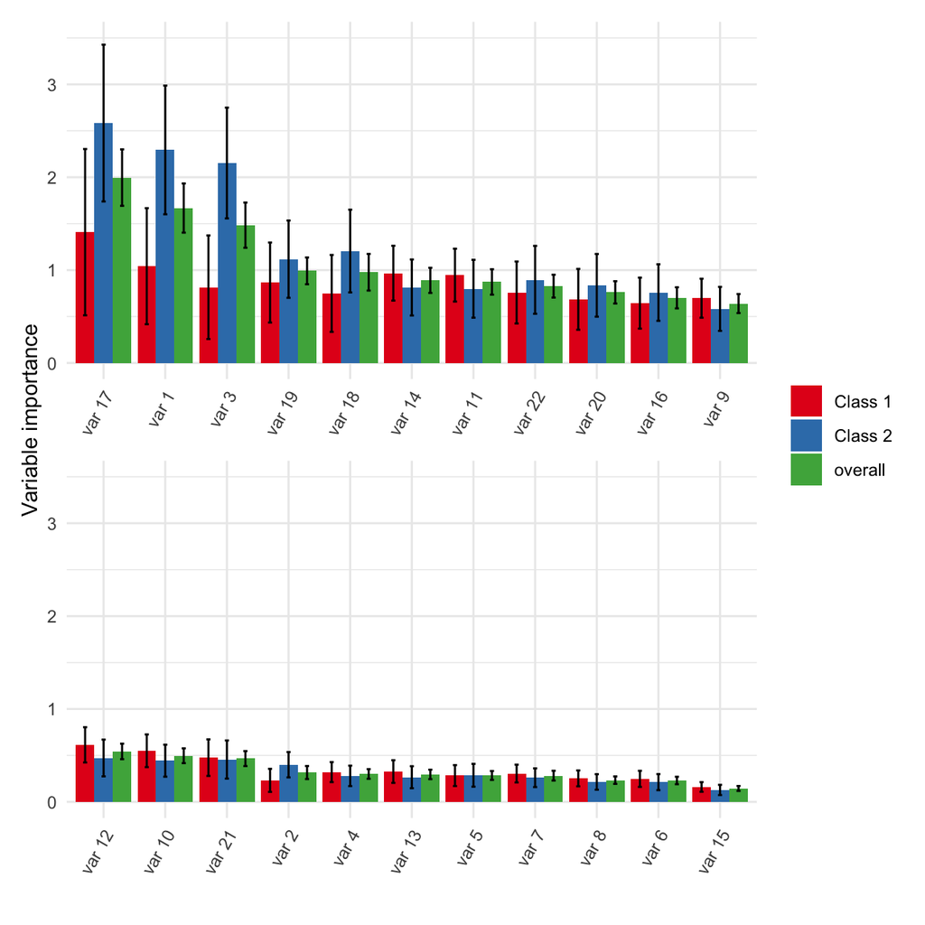

```r
# get mean varimp
imp_vars = lapply(RCE_result, function(x) x$imp_var)
vimp_mean = Reduce("+", imp_vars) / 200
# get stdev
vimp_stdev = apply(simplify2array(imp_vars), c(1, 2), sd)
vimp_stdev_overall = apply(sapply(imp_vars, function(x) apply(x, 2, mean)), 1, sd)

tmp = data.frame(varnum=paste('var', 1:ncol(vimp_mean)),
                 mean=t(vimp_mean),
                 sd=t(vimp_stdev),
                 mean.overall=apply(t(vimp_mean), 1, mean),
                 sd.overall=vimp_stdev_overall
)
tmp_overall = tmp[,c(1,6,7)] %>%
    arrange(-mean.overall)
tmp = rbind(
      setNames(tmp[,c(1,2,4)], c("varnum", "mean", "sd")),
      setNames(tmp[,c(1,3,5)], c("varnum", "mean", "sd")),
      setNames(tmp[,c(1,6,7)], c("varnum", "mean", "sd"))
)
tmp$type = rep(c("Class 1", "Class 2", "overall"), each=nrow(tmp)/3)
tmp$varnum = factor(tmp$varnum, levels=tmp_overall$varnum)

p1 = ggplot(tmp %>% filter(varnum %in% tmp_overall$varnum[1:11])) +
    geom_bar(aes(x=varnum, y=mean, fill=type),
             stat="identity",
             position=position_dodge()) +
    geom_errorbar(aes(x=varnum, ymin=mean-sd, ymax=mean+sd, group=type), width=.2,
             position=position_dodge(width=0.9)) +
    xlab("") +
    ylim(0, 3.5) +
    ylab("Variable importance") +
    scale_fill_brewer(name="", palette="Set1") +
    theme_minimal() +
    theme(axis.text.x = element_text(angle=60, hjust=1, vjust=1))
p2 = ggplot(tmp %>% filter(varnum %in% tmp_overall$varnum[12:22])) +
    geom_bar(aes(x=varnum, y=mean, fill=type),
             stat="identity",
             position=position_dodge()) +
    geom_errorbar(aes(x=varnum, ymin=mean-sd, ymax=mean+sd, group=type), width=.2,
             position=position_dodge(width=0.9)) +
    xlab("") +
    ylab("Variable importance") +
    ylim(0, 3.5) +
    scale_fill_brewer(name="", palette="Set1") +
    theme_minimal() +
    theme(axis.text.x = element_text(angle=60, hjust=1, vjust=1))
p1 / p2 + plot_layout(guides='collect', axis_titles='collect')
```

Here, the bars represent the mean variable importance over 200 runs of RCE (`nbag`=200) and the error bars represent the standard deviation of the variable importance.

**Rerun with larger `nbag`**

```r
set.seed(42)
RCE_result2 = mclapply(1:200, function(i) RCE(data_path="../example_data/Bases/parkinson.txt",
                                             nbiter=400,
                                             vfun=ic))
```

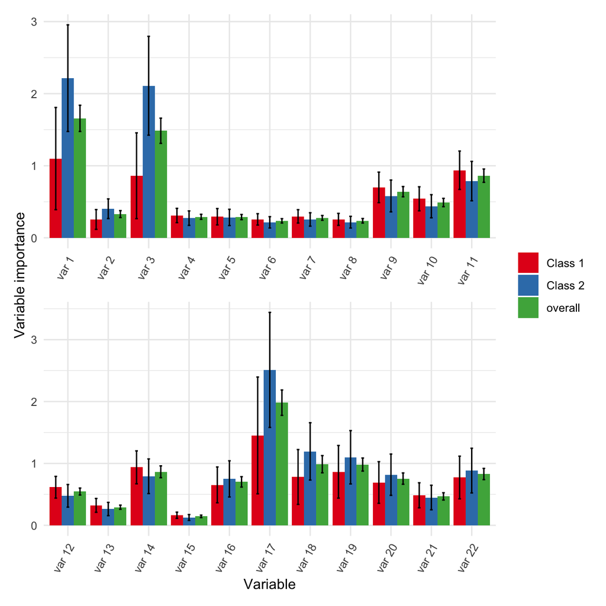

```r
# get mean varimp
imp_vars2 = lapply(RCE_result2, function(x) x$imp_var)
vimp_mean = Reduce("+", imp_vars2) / 200
# get stdev
vimp_stdev = apply(simplify2array(imp_vars2), c(1, 2), sd)
vimp_stdev_overall = apply(sapply(imp_vars2, function(x) apply(x, 2, mean)), 1, sd)

tmp = data.frame(varnum=paste('var', 1:ncol(vimp_mean)),
                 mean=t(vimp_mean),
                 sd=t(vimp_stdev),
                 mean.overall=apply(t(vimp_mean), 1, mean),
                 sd.overall=vimp_stdev_overall
)
tmp = rbind(
      setNames(tmp[,c(1,2,4)], c("varnum", "mean", "sd")),
      setNames(tmp[,c(1,3,5)], c("varnum", "mean", "sd")),
      setNames(tmp[,c(1,6,7)], c("varnum", "mean", "sd"))
)
tmp$type = rep(c("Class 1", "Class 2", "overall"), each=nrow(tmp)/3)
tmp$varnum = factor(tmp$varnum, levels=paste('var', 1:ncol(vimp_mean)))

p1 = ggplot(tmp %>% filter(varnum %in% paste('var', 1:11))) +
    geom_bar(aes(x=varnum, y=mean, fill=type),
             stat="identity",
             position=position_dodge()) +
    geom_errorbar(aes(x=varnum, ymin=mean-sd, ymax=mean+sd, group=type), width=.2,
             position=position_dodge(width=0.9)) +
    xlab("Variable") +
    ylab("Variable importance") +
    scale_fill_brewer(name="", palette="Set1") +
    theme_minimal() +
    theme(axis.text.x = element_text(angle=60, hjust=1, vjust=1))
p2 = ggplot(tmp %>% filter(varnum %in% paste('var', 12:22))) +
    geom_bar(aes(x=varnum, y=mean, fill=type),
             stat="identity",
             position=position_dodge()) +
    geom_errorbar(aes(x=varnum, ymin=mean-sd, ymax=mean+sd, group=type), width=.2,
             position=position_dodge(width=0.9)) +
    xlab("Variable") +
    ylab("Variable importance") +
    scale_fill_brewer(name="", palette="Set1") +
    theme_minimal() +
    theme(axis.text.x = element_text(angle=60, hjust=1, vjust=1))
p1 / p2 + plot_layout(guides='collect', axis_titles='collect')
```

*Observations*

- The variable importance varies a lot, with large error bars for the most important variables.
- It seems like the variability of var importance does not decrease much with increasing the bagging iterations from 200 to 400

## 2.2 Scree test stability

The authors of the paper use the scree plot as a hard limit to differentiate kept variables and not kept variables.

Some details about their usage of the scree (elbow) method:

- elbow point is calculated using the double derivative method
- elbow points and cutoffs are calculated separately for different clusters
  - this doesn’t make a lot of sense to me in a two class problem such as Parkinsons
- the different sets of important variables obtained for the different clusters are then combined to form the superset which is returned

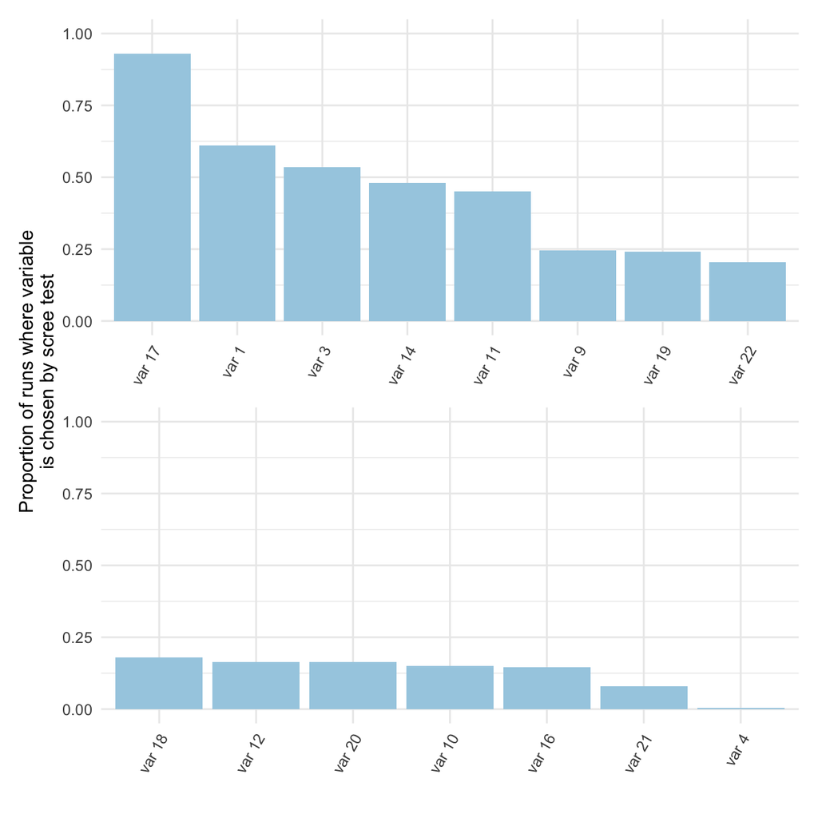

```r
tmp = data.frame(proportion=sort(table(unlist(map(imp_vars, ~ scree_test(.x)$sf_unique))) / 200,
                                 decreasing=T)) %>%
    setNames(c("varnum", "proportion")) %>%
    mutate(varnum = factor(paste('var', varnum), levels=paste('var', varnum)))

p1 = ggplot(tmp[1:8,]) +
    geom_bar(aes(x=varnum, y=proportion, fill='1'),
             stat="identity",
             position=position_dodge()) +
    xlab("") +
    ylim(0, 1) +
    ylab("Proportion of runs where variable\nis chosen by scree test") +
    scale_fill_brewer(name="", palette="Paired", guide="none") +
    theme_minimal() +
    theme(axis.text.x = element_text(angle=60, hjust=1, vjust=1))
p2 = ggplot(tmp[9:nrow(tmp),]) +
    geom_bar(aes(x=varnum, y=proportion, fill='1'),
             stat="identity",
             position=position_dodge()) +
    xlab("") +
    ylim(0, 1) +
    ylab("Proportion of runs where variable\nis chosen by scree test") +
    scale_fill_brewer(name="", palette="Paired", guide="none") +
    theme_minimal() +
    theme(axis.text.x = element_text(angle=60, hjust=1, vjust=1))
p1 / p2 + plot_layout(guides='collect', axis_titles='collect')
```

*Observations*

- Even the most important variable (var 17) is not chosen all of the time by the scree test

# 3 Breast tissue data set

[link to UCI data set](https://archive.ics.uci.edu/dataset/192/breast+tissue)

Note: this is not the better-studied Wisconsin breast cancer data set (which I originally mistook it for) that has only two classes.

## 3.1 Variable importance

```r
set.seed(42)
RCE_breast = mclapply(1:200, function(i) RCE(data_path="../example_data/Bases/Breast_Tissu.txt",
                                             nbiter=200,
                                             vfun=ic))
```

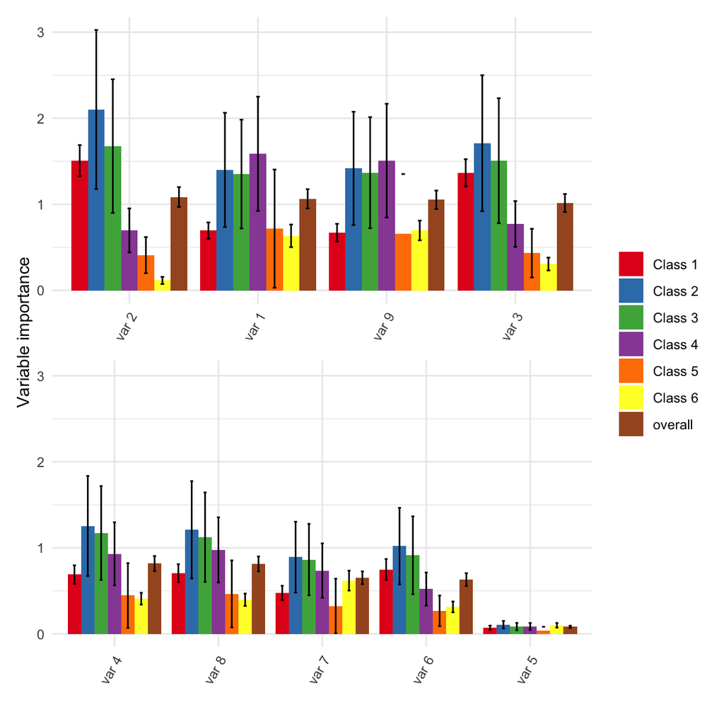

```r
# get mean varimp
imp_vars2 = lapply(RCE_breast, function(x) x$imp_var)
vimp_mean = Reduce("+", imp_vars2) / 200
# get stdev
vimp_stdev = apply(simplify2array(imp_vars2), c(1, 2), sd)
vimp_stdev_overall = apply(sapply(imp_vars2, function(x) apply(x, 2, mean)), 1, sd)

d = ncol(vimp_mean)
nclass = nrow(vimp_mean)

tmp = data.frame(varnum=paste('var', 1:ncol(vimp_mean)),
                 mean=c(c(t(vimp_mean)), apply(t(vimp_mean), 1, mean)),
                 sd=c(c(t(vimp_stdev)), vimp_stdev_overall)
)
tmp$type = rep(c(paste('Class', 1:nclass), 'overall'), each=d)
tmp_overall = tmp %>%
    filter(type == 'overall') %>%
    arrange(-mean)
tmp$varnum = factor(tmp$varnum, levels=tmp_overall$varnum)

p1 = ggplot(tmp %>% filter(varnum %in% tmp_overall$varnum[1:floor(d/2)])) +
    geom_bar(aes(x=varnum, y=mean, fill=type),
             stat="identity",
             position=position_dodge()) +
    geom_errorbar(aes(x=varnum, ymin=mean-sd, ymax=mean+sd, group=type), width=.2,
             position=position_dodge(width=0.9)) +
    xlab("") +
    ylim(0, max(tmp$mean + tmp$sd)) +
    ylab("Variable importance") +
    scale_fill_brewer(name="", palette="Set1") +
    theme_minimal() +
    theme(axis.text.x = element_text(angle=60, hjust=1, vjust=1))
p2 = ggplot(tmp %>% filter(varnum %in% tmp_overall$varnum[(floor(d/2)+1):d])) +
    geom_bar(aes(x=varnum, y=mean, fill=type),
             stat="identity",
             position=position_dodge()) +
    geom_errorbar(aes(x=varnum, ymin=mean-sd, ymax=mean+sd, group=type), width=.2,
             position=position_dodge(width=0.9)) +
    xlab("") +
    ylab("Variable importance") +
    ylim(0, max(tmp$mean + tmp$sd)) +
    scale_fill_brewer(name="", palette="Set1") +
    theme_minimal() +
    theme(axis.text.x = element_text(angle=60, hjust=1, vjust=1))
p1 / p2 + plot_layout(guides='collect', axis_titles='collect')
```

## 3.2 Scree test stability

```r
#' @param tab table of times a scree test was chosen
plot_scree = function(tab, ntotal=200, title=NULL) {
    tab = sort(tab / ntotal, decreasing=T)
    tmp = data.frame(proportion=tab) %>%
    setNames(c("varnum", "proportion")) %>%
    mutate(varnum = factor(paste('var', varnum), levels=paste('var', varnum)))

    p1 = ggplot(tmp[1:floor(nrow(tmp)/2),]) +
        geom_bar(aes(x=varnum, y=proportion, fill='1'),
                 stat="identity",
                 position=position_dodge()) +
        xlab("") +
        ylim(0, 1) +
        ylab("Proportion of runs where variable\nis chosen by scree test") +
        scale_fill_brewer(name="", palette="Paired", guide="none") +
        theme_minimal() +
        theme(axis.text.x = element_text(angle=60, hjust=1, vjust=1))
    if(!is.null(title)) { p1 = p1 + ggtitle(title) }
    p2 = ggplot(tmp[(floor(nrow(tmp)/2)+1):nrow(tmp),]) +
        geom_bar(aes(x=varnum, y=proportion, fill='1'),
                 stat="identity",
                 position=position_dodge()) +
        xlab("") +
        ylim(0, 1) +
        ylab("Proportion of runs where variable\nis chosen by scree test") +
        scale_fill_brewer(name="", palette="Paired", guide="none") +
        theme_minimal() +
        theme(axis.text.x = element_text(angle=60, hjust=1, vjust=1))
    p1 / p2 + plot_layout(guides='collect', axis_titles='collect')
}
```

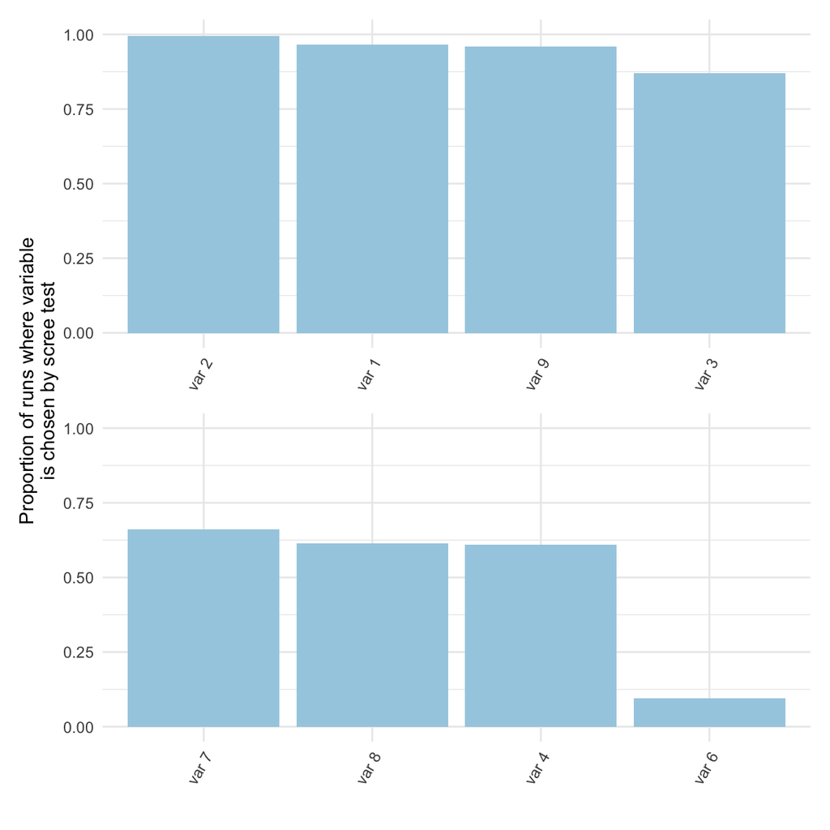

```r
plot_scree(table(unlist(map(imp_vars2, ~ scree_test(.x)$sf_unique))))
```

*Observations*

- Var 5 is never chosen, and var 6 is rarely chosen
- Var 2 is almost always chosen
- My interpretation of this is that the scree test is not very stable if we conduct only a single run, as there is a small chance we would miss variables that are most important (var 2 for breast tissue and var 17 for Parkinson), and other potentially important variables (var 1, 3, 14 for Parkinson and var 7, 8, 4 for breast tissue) may have around 50% chance of being chosen.

# 4 Edit to scree test

I wonder if taking the mean (or even max) importance across variables and then applying the scree test yields a more consistent result. I think mean could work, but it may obscure variables that are only important for distinguishing a single class. Although, this logic doesn’t make sense given that we do not have *a priori* class labels.

## 4.1 Mean test

Here, we take the mean of the variable importance across classes before performing the scree test.

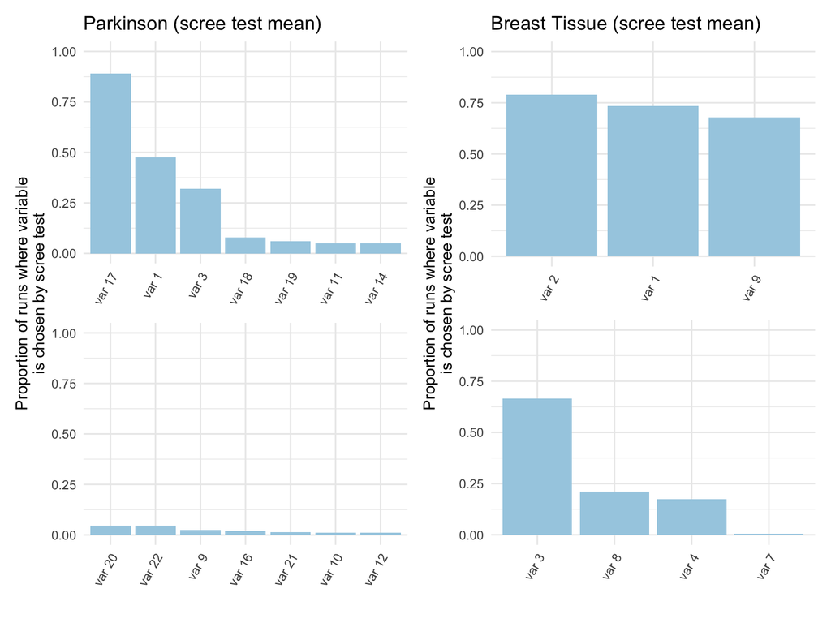

```r
p1 = plot_scree(table(unlist(map(imp_vars, ~ scree_test(apply(.x, 2, mean))$sf_unique))),
    title="Parkinson (scree test mean)")
p2 = plot_scree(table(unlist(map(imp_vars2, ~ scree_test(apply(.x, 2, mean))$sf_unique))),
    title="Breast Tissue (scree test mean)")
p1 | p2
```

## 4.2 Max test

Here, we take the max of the variable importance across classes before performing the scree test.

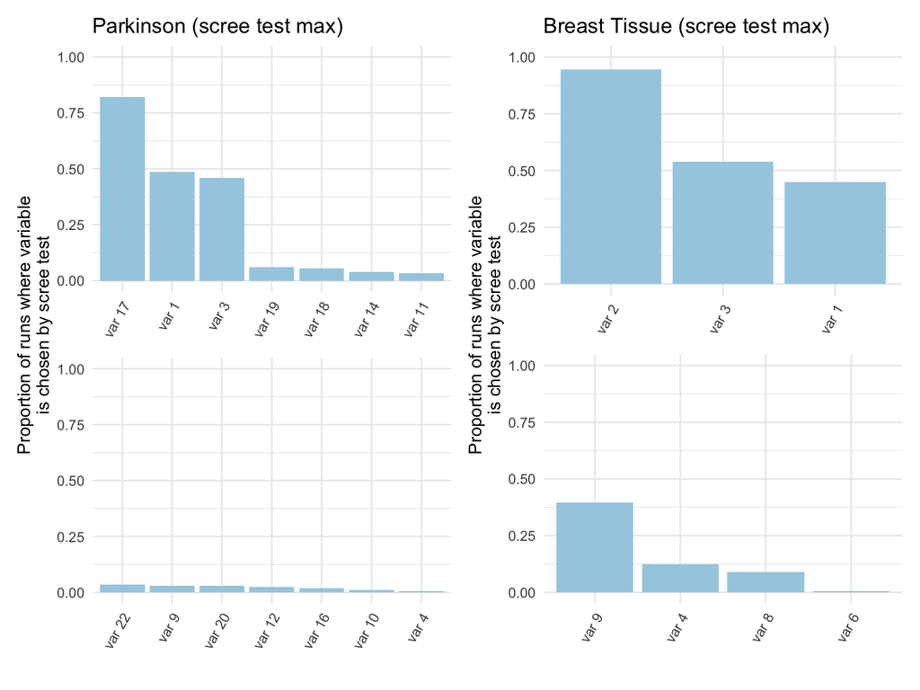

```r
p1 = plot_scree(table(unlist(map(imp_vars, ~ scree_test(apply(.x, 2, max))$sf_unique))),
    title="Parkinson (scree test max)")
p2 = plot_scree(table(unlist(map(imp_vars2, ~ scree_test(apply(.x, 2, max))$sf_unique))),
    title="Breast Tissue (scree test max)")
p1 | p2
```

## 4.3 Thoughts

# 5 Some questions

- Why can variable importance be greater than 1?
  - I thought that variable importance was calculated via permutation of times a permuting a variable changes the cluster assignment for a given sample OOB - divided by the times a sample was OOB.
- Is there a pattern to when variables are chosen by the scree test? i.e., is var 7 always chosen when var 8 is not chosen, etc.